# Optimal Treatment Analysis

## Outcome Variable

**Outcome Variable:** whz

## Predictor Variables

**Intervention Variable:** feducyrs

**Adjustment Set:**

- arm
- W_mage
- meducyrs
- W_mhtcm
- W_gagebrth
- W_birthwt
- W_birthlen
- single
- delta_W_mage
- delta_meducyrs
- delta_W_mhtcm
- delta_W_gagebrth
- delta_W_birthwt
- delta_W_birthlen
- delta_single

## Stratifying Variables

The analysis was stratified on these variable(s):

- agecat
- studyid
- country

## Data Summary

| agecat | studyid | country | feducyrs | n_cell | n |
| --- | --- | --- | --- | --- | --- |
| Birth | ki0047075b-MAL-ED | BANGLADESH | High | 49 | 134 |
| Birth | ki0047075b-MAL-ED | BANGLADESH | Low | 35 | 134 |
| Birth | ki0047075b-MAL-ED | BANGLADESH | Medium | 50 | 134 |
| Birth | ki0047075b-MAL-ED | INDIA | High | 38 | 121 |
| Birth | ki0047075b-MAL-ED | INDIA | Low | 48 | 121 |
| Birth | ki0047075b-MAL-ED | INDIA | Medium | 35 | 121 |
| Birth | ki0047075b-MAL-ED | NEPAL | High | 27 | 64 |
| Birth | ki0047075b-MAL-ED | NEPAL | Low | 18 | 64 |
| Birth | ki0047075b-MAL-ED | NEPAL | Medium | 19 | 64 |
| Birth | ki0047075b-MAL-ED | PERU | High | 112 | 230 |
| Birth | ki0047075b-MAL-ED | PERU | Low | 63 | 230 |
| Birth | ki0047075b-MAL-ED | PERU | Medium | 55 | 230 |
| Birth | ki0047075b-MAL-ED | SOUTH AFRICA | High | 35 | 91 |
| Birth | ki0047075b-MAL-ED | SOUTH AFRICA | Low | 30 | 91 |
| Birth | ki0047075b-MAL-ED | SOUTH AFRICA | Medium | 26 | 91 |
| Birth | ki0047075b-MAL-ED | TANZANIA, UNITED REPUBLIC OF | High | 63 | 96 |
| Birth | ki0047075b-MAL-ED | TANZANIA, UNITED REPUBLIC OF | Low | 27 | 96 |
| Birth | ki0047075b-MAL-ED | TANZANIA, UNITED REPUBLIC OF | Medium | 6 | 96 |
| Birth | ki1000304b-SAS-CompFeed | INDIA | High | 33 | 166 |
| Birth | ki1000304b-SAS-CompFeed | INDIA | Low | 68 | 166 |
| Birth | ki1000304b-SAS-CompFeed | INDIA | Medium | 65 | 166 |
| Birth | ki1017093c-NIH-Crypto | BANGLADESH | High | 7 | 23 |
| Birth | ki1017093c-NIH-Crypto | BANGLADESH | Low | 11 | 23 |
| Birth | ki1017093c-NIH-Crypto | BANGLADESH | Medium | 5 | 23 |
| Birth | ki1119695-PROBIT | BELARUS | High | 2050 | 13359 |
| Birth | ki1119695-PROBIT | BELARUS | Low | 5294 | 13359 |
| Birth | ki1119695-PROBIT | BELARUS | Medium | 6015 | 13359 |
| Birth | ki1126311-ZVITAMBO | ZIMBABWE | High | 914 | 12572 |
| Birth | ki1126311-ZVITAMBO | ZIMBABWE | Low | 2090 | 12572 |
| Birth | ki1126311-ZVITAMBO | ZIMBABWE | Medium | 9568 | 12572 |

[output cut: 129 more lines]

The following strata were considered:

- agecat: 24 months, studyid: ki0047075b-MAL-ED, country: BANGLADESH
- agecat: 24 months, studyid: ki0047075b-MAL-ED, country: INDIA
- agecat: 24 months, studyid: ki0047075b-MAL-ED, country: NEPAL
- agecat: 24 months, studyid: ki0047075b-MAL-ED, country: PERU
- agecat: 24 months, studyid: ki0047075b-MAL-ED, country: SOUTH AFRICA
- agecat: 24 months, studyid: ki0047075b-MAL-ED, country: TANZANIA, UNITED REPUBLIC OF
- agecat: 24 months, studyid: ki1017093b-PROVIDE, country: BANGLADESH
- agecat: 24 months, studyid: ki1017093c-NIH-Crypto, country: BANGLADESH
- agecat: 24 months, studyid: ki1066203-TanzaniaChild2, country: TANZANIA, UNITED REPUBLIC OF
- agecat: 24 months, studyid: ki1113344-GMS-Nepal, country: NEPAL
- agecat: 24 months, studyid: ki1119695-PROBIT, country: BELARUS
- agecat: 24 months, studyid: ki1126311-ZVITAMBO, country: ZIMBABWE
- agecat: 24 months, studyid: ki1135781-COHORTS, country: GUATEMALA
- agecat: 24 months, studyid: ki1135781-COHORTS, country: INDIA
- agecat: 24 months, studyid: ki1135781-COHORTS, country: PHILIPPINES
- agecat: 24 months, studyid: ki1148112-LCNI-5, country: MALAWI
- agecat: 24 months, studyid: kiGH5241-JiVitA-3, country: BANGLADESH
- agecat: 24 months, studyid: kiGH5241-JiVitA-4, country: BANGLADESH
- agecat: 6 months, studyid: ki0047075b-MAL-ED, country: BANGLADESH
- agecat: 6 months, studyid: ki0047075b-MAL-ED, country: INDIA
- agecat: 6 months, studyid: ki0047075b-MAL-ED, country: NEPAL
- agecat: 6 months, studyid: ki0047075b-MAL-ED, country: PERU
- agecat: 6 months, studyid: ki0047075b-MAL-ED, country: SOUTH AFRICA
- agecat: 6 months, studyid: ki0047075b-MAL-ED, country: TANZANIA, UNITED REPUBLIC OF
- agecat: 6 months, studyid: ki1000304b-SAS-CompFeed, country: INDIA
- agecat: 6 months, studyid: ki1000304b-SAS-FoodSuppl, country: INDIA
- agecat: 6 months, studyid: ki1017093b-PROVIDE, country: BANGLADESH
- agecat: 6 months, studyid: ki1017093c-NIH-Crypto, country: BANGLADESH
- agecat: 6 months, studyid: ki1066203-TanzaniaChild2, country: TANZANIA, UNITED REPUBLIC OF
- agecat: 6 months, studyid: ki1113344-GMS-Nepal, country: NEPAL
- agecat: 6 months, studyid: ki1119695-PROBIT, country: BELARUS
- agecat: 6 months, studyid: ki1126311-ZVITAMBO, country: ZIMBABWE
- agecat: 6 months, studyid: ki1135781-COHORTS, country: GUATEMALA
- agecat: 6 months, studyid: ki1135781-COHORTS, country: INDIA
- agecat: 6 months, studyid: ki1135781-COHORTS, country: PHILIPPINES
- agecat: 6 months, studyid: ki1148112-LCNI-5, country: MALAWI
- agecat: 6 months, studyid: kiGH5241-JiVitA-3, country: BANGLADESH
- agecat: 6 months, studyid: kiGH5241-JiVitA-4, country: BANGLADESH
- agecat: Birth, studyid: ki0047075b-MAL-ED, country: BANGLADESH
- agecat: Birth, studyid: ki0047075b-MAL-ED, country: INDIA
- agecat: Birth, studyid: ki0047075b-MAL-ED, country: NEPAL
- agecat: Birth, studyid: ki0047075b-MAL-ED, country: PERU
- agecat: Birth, studyid: ki0047075b-MAL-ED, country: SOUTH AFRICA
- agecat: Birth, studyid: ki0047075b-MAL-ED, country: TANZANIA, UNITED REPUBLIC OF
- agecat: Birth, studyid: ki1000304b-SAS-CompFeed, country: INDIA
- agecat: Birth, studyid: ki1017093c-NIH-Crypto, country: BANGLADESH
- agecat: Birth, studyid: ki1119695-PROBIT, country: BELARUS
- agecat: Birth, studyid: ki1126311-ZVITAMBO, country: ZIMBABWE
- agecat: Birth, studyid: ki1135781-COHORTS, country: GUATEMALA
- agecat: Birth, studyid: ki1135781-COHORTS, country: INDIA
- agecat: Birth, studyid: ki1135781-COHORTS, country: PHILIPPINES
- agecat: Birth, studyid: kiGH5241-JiVitA-3, country: BANGLADESH
- agecat: Birth, studyid: kiGH5241-JiVitA-4, country: BANGLADESH

### Dropped Strata

Some strata were dropped due to rare outcomes:

- agecat: 24 months, studyid: ki1066203-TanzaniaChild2, country: TANZANIA, UNITED REPUBLIC OF

## Methods Detail

We’re interested in the causal parameters $E[Y_a]$ for all values of $a \in \mathcal{A}$. These parameters represent the mean outcome if, possibly contrary to fact, we intervened to set all units to have $A=a$. Under the randomization and positivity assumptions, these are identified by the statistical parameters $\psi_a=E_W[E_{Y|A,W}(Y|A=a,W)]$. In addition, we’re interested in the mean of $Y$, $E[Y]$ under no intervention (the observed mean). We will estimate these parameters by using SuperLearner to fit the relevant likelihood factors – $E_{Y|A,W}(Y|A=a,W)$ and $p(A=a|W)$, and then updating our likelihood fit using a joint TMLE.

For unadjusted analyses ($W=\{\}$), initial likelihoods were estimated using Lrnr_glm to estimate the simple $E(Y|A)$ and Lrnr_mean to estimate $p(A)$. For adjusted analyses, a small library containing Lrnr_glmnet, Lrnr_xgboost, and Lrnr_mean was used.

# Results Detail

## Results Plots

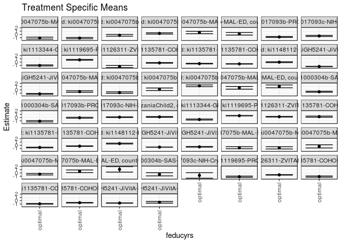

## Results Table

### Parameter: TSM

| agecat | studyid | country | intervention_level | baseline_level | estimate | ci_lower | ci_upper |
| --- | --- | --- | --- | --- | --- | --- | --- |
| Birth | ki0047075b-MAL-ED | BANGLADESH | optimal | observed | -0.7378177 | -1.0508674 | -0.4247681 |
| Birth | ki0047075b-MAL-ED | INDIA | optimal | observed | -0.7816216 | -1.1280918 | -0.4351514 |
| Birth | ki0047075b-MAL-ED | NEPAL | optimal | observed | -0.3349011 | -0.8191356 | 0.1493334 |
| Birth | ki0047075b-MAL-ED | PERU | optimal | observed | -0.3614197 | -0.5933930 | -0.1294464 |
| Birth | ki0047075b-MAL-ED | SOUTH AFRICA | optimal | observed | 0.5263903 | 0.1261768 | 0.9266038 |
| Birth | ki0047075b-MAL-ED | TANZANIA, UNITED REPUBLIC OF | optimal | observed | 1.1071259 | 0.2756432 | 1.9386085 |
| Birth | ki1000304b-SAS-CompFeed | INDIA | optimal | observed | -0.4029282 | -0.8861945 | 0.0803380 |
| Birth | ki1017093c-NIH-Crypto | BANGLADESH | optimal | observed | -0.7401059 | -1.5726958 | 0.0924839 |
| Birth | ki1119695-PROBIT | BELARUS | optimal | observed | -1.1342012 | -1.3295845 | -0.9388179 |
| Birth | ki1126311-ZVITAMBO | ZIMBABWE | optimal | observed | -0.5688286 | -0.6406713 | -0.4969858 |
| Birth | ki1135781-COHORTS | GUATEMALA | optimal | observed | -1.0952768 | -1.2829717 | -0.9075820 |
| Birth | ki1135781-COHORTS | INDIA | optimal | observed | -0.9492834 | -1.0567543 | -0.8418125 |
| Birth | ki1135781-COHORTS | PHILIPPINES | optimal | observed | -0.6081973 | -0.6922268 | -0.5241678 |
| Birth | kiGH5241-JiVitA-3 | BANGLADESH | optimal | observed | -0.7169441 | -0.7535259 | -0.6803623 |
| Birth | kiGH5241-JiVitA-4 | BANGLADESH | optimal | observed | -0.4870582 | -0.7442160 | -0.2299003 |
| 6 months | ki0047075b-MAL-ED | BANGLADESH | optimal | observed | -0.5220035 | -0.7499444 | -0.2940625 |
| 6 months | ki0047075b-MAL-ED | INDIA | optimal | observed | -0.8278019 | -1.0544259 | -0.6011779 |
| 6 months | ki0047075b-MAL-ED | NEPAL | optimal | observed | 0.1885936 | -0.1961725 | 0.5733598 |
| 6 months | ki0047075b-MAL-ED | PERU | optimal | observed | 1.2360544 | 0.9569771 | 1.5151316 |
| 6 months | ki0047075b-MAL-ED | SOUTH AFRICA | optimal | observed | 0.6237396 | 0.2118353 | 1.0356440 |
| 6 months | ki0047075b-MAL-ED | TANZANIA, UNITED REPUBLIC OF | optimal | observed | 1.0673187 | 0.6287646 | 1.5058729 |
| 6 months | ki1000304b-SAS-CompFeed | INDIA | optimal | observed | -0.5789834 | -0.7312222 | -0.4267445 |
| 6 months | ki1000304b-SAS-FoodSuppl | INDIA | optimal | observed | -1.1213549 | -1.3181115 | -0.9245983 |
| 6 months | ki1017093b-PROVIDE | BANGLADESH | optimal | observed | -0.0454304 | -0.1934712 | 0.1026105 |
| 6 months | ki1017093c-NIH-Crypto | BANGLADESH | optimal | observed | 0.1157615 | -0.0073937 | 0.2389167 |
| 6 months | ki1066203-TanzaniaChild2 | TANZANIA, UNITED REPUBLIC OF | optimal | observed | 0.1968448 | 0.0819078 | 0.3117818 |
| 6 months | ki1113344-GMS-Nepal | NEPAL | optimal | observed | -0.5872230 | -0.7466424 | -0.4278036 |
| 6 months | ki1119695-PROBIT | BELARUS | optimal | observed | 0.5648519 | 0.5040562 | 0.6256476 |
| 6 months | ki1126311-ZVITAMBO | ZIMBABWE | optimal | observed | 0.2585321 | 0.1719969 | 0.3450673 |
| 6 months | ki1135781-COHORTS | GUATEMALA | optimal | observed | 0.2815967 | 0.1100325 | 0.4531609 |
| 6 months | ki1135781-COHORTS | INDIA | optimal | observed | -0.6711965 | -0.7777183 | -0.5646747 |
| 6 months | ki1135781-COHORTS | PHILIPPINES | optimal | observed | -0.2622713 | -0.3347134 | -0.1898293 |
| 6 months | ki1148112-LCNI-5 | MALAWI | optimal | observed | 0.5262809 | 0.3923694 | 0.6601925 |
| 6 months | kiGH5241-JiVitA-3 | BANGLADESH | optimal | observed | -0.5586057 | -0.5960491 | -0.5211622 |
| 6 months | kiGH5241-JiVitA-4 | BANGLADESH | optimal | observed | -0.4774966 | -0.5619318 | -0.3930614 |
| 24 months | ki0047075b-MAL-ED | BANGLADESH | optimal | observed | -1.1162025 | -1.4064223 | -0.8259827 |
| 24 months | ki0047075b-MAL-ED | INDIA | optimal | observed | -1.1160162 | -1.3187826 | -0.9132498 |
| 24 months | ki0047075b-MAL-ED | NEPAL | optimal | observed | -0.2604678 | -0.5306891 | 0.0097536 |
| 24 months | ki0047075b-MAL-ED | PERU | optimal | observed | 0.3087806 | 0.1070953 | 0.5104659 |
| 24 months | ki0047075b-MAL-ED | SOUTH AFRICA | optimal | observed | 0.6013756 | 0.2303182 | 0.9724331 |
| 24 months | ki0047075b-MAL-ED | TANZANIA, UNITED REPUBLIC OF | optimal | observed | 0.1852474 | -0.2020457 | 0.5725406 |
| 24 months | ki1017093b-PROVIDE | BANGLADESH | optimal | observed | -0.7731636 | -0.9118846 | -0.6344426 |
| 24 months | ki1017093c-NIH-Crypto | BANGLADESH | optimal | observed | -0.4610182 | -0.6209933 | -0.3010430 |
| 24 months | ki1113344-GMS-Nepal | NEPAL | optimal | observed | -1.0131090 | -1.1759589 | -0.8502591 |
| 24 months | ki1119695-PROBIT | BELARUS | optimal | observed | 0.6962860 | 0.5752572 | 0.8173148 |
| 24 months | ki1126311-ZVITAMBO | ZIMBABWE | optimal | observed | -1.3451036 | -1.6744125 | -1.0157947 |
| 24 months | ki1135781-COHORTS | GUATEMALA | optimal | observed | -0.2310865 | -0.3326069 | -0.1295661 |
| 24 months | ki1135781-COHORTS | INDIA | optimal | observed | -0.4586340 | -0.5403030 | -0.3769650 |
| 24 months | ki1135781-COHORTS | PHILIPPINES | optimal | observed | -0.5378967 | -0.5971919 | -0.4786014 |
| 24 months | ki1148112-LCNI-5 | MALAWI | optimal | observed | -0.0027561 | -0.1404724 | 0.1349603 |
| 24 months | kiGH5241-JiVitA-3 | BANGLADESH | optimal | observed | -1.3305632 | -1.3740603 | -1.2870660 |
| 24 months | kiGH5241-JiVitA-4 | BANGLADESH | optimal | observed | -1.2102516 | -1.3313526 | -1.0891506 |

### Parameter: E(Y)

| agecat | studyid | country | intervention_level | baseline_level | estimate | ci_lower | ci_upper |
| --- | --- | --- | --- | --- | --- | --- | --- |
| Birth | ki0047075b-MAL-ED | BANGLADESH | observed | observed | -0.9578358 | -1.1387078 | -0.7769639 |
| Birth | ki0047075b-MAL-ED | INDIA | observed | observed | -0.9940496 | -1.1654347 | -0.8226645 |
| Birth | ki0047075b-MAL-ED | NEPAL | observed | observed | -0.6120312 | -0.8275323 | -0.3965302 |
| Birth | ki0047075b-MAL-ED | PERU | observed | observed | -0.0617391 | -0.1779184 | 0.0544402 |
| Birth | ki0047075b-MAL-ED | SOUTH AFRICA | observed | observed | 0.1956044 | -0.0084906 | 0.3996994 |
| Birth | ki0047075b-MAL-ED | TANZANIA, UNITED REPUBLIC OF | observed | observed | 0.7337500 | 0.5184571 | 0.9490429 |
| Birth | ki1000304b-SAS-CompFeed | INDIA | observed | observed | -0.2697590 | -0.5399211 | 0.0004030 |
| Birth | ki1017093c-NIH-Crypto | BANGLADESH | observed | observed | -0.7508696 | -1.2358912 | -0.2658480 |
| Birth | ki1119695-PROBIT | BELARUS | observed | observed | -1.1411895 | -1.3517005 | -0.9306784 |
| Birth | ki1126311-ZVITAMBO | ZIMBABWE | observed | observed | -0.5089119 | -0.5350685 | -0.4827552 |
| Birth | ki1135781-COHORTS | GUATEMALA | observed | observed | -1.0475905 | -1.1510656 | -0.9441155 |
| Birth | ki1135781-COHORTS | INDIA | observed | observed | -1.0020759 | -1.0646599 | -0.9394920 |
| Birth | ki1135781-COHORTS | PHILIPPINES | observed | observed | -0.7218585 | -0.7694262 | -0.6742908 |
| Birth | kiGH5241-JiVitA-3 | BANGLADESH | observed | observed | -0.7212256 | -0.7411702 | -0.7012810 |
| Birth | kiGH5241-JiVitA-4 | BANGLADESH | observed | observed | -0.3724538 | -0.4743874 | -0.2705203 |
| 6 months | ki0047075b-MAL-ED | BANGLADESH | observed | observed | -0.3053662 | -0.4828374 | -0.1278949 |
| 6 months | ki0047075b-MAL-ED | INDIA | observed | observed | -0.7164734 | -0.8860809 | -0.5468660 |
| 6 months | ki0047075b-MAL-ED | NEPAL | observed | observed | 0.0313158 | -0.1673661 | 0.2299977 |
| 6 months | ki0047075b-MAL-ED | PERU | observed | observed | 1.0866741 | 0.9521834 | 1.2211648 |
| 6 months | ki0047075b-MAL-ED | SOUTH AFRICA | observed | observed | 0.3830435 | 0.1435272 | 0.6225598 |
| 6 months | ki0047075b-MAL-ED | TANZANIA, UNITED REPUBLIC OF | observed | observed | 0.5218823 | 0.3795317 | 0.6642328 |
| 6 months | ki1000304b-SAS-CompFeed | INDIA | observed | observed | -0.6641059 | -0.8040033 | -0.5242086 |
| 6 months | ki1000304b-SAS-FoodSuppl | INDIA | observed | observed | -1.0121579 | -1.1280429 | -0.8962729 |
| 6 months | ki1017093b-PROVIDE | BANGLADESH | observed | observed | -0.2083706 | -0.2927992 | -0.1239419 |
| 6 months | ki1017093c-NIH-Crypto | BANGLADESH | observed | observed | 0.0297622 | -0.0491685 | 0.1086930 |
| 6 months | ki1066203-TanzaniaChild2 | TANZANIA, UNITED REPUBLIC OF | observed | observed | 0.0791782 | 0.0263777 | 0.1319787 |
| 6 months | ki1113344-GMS-Nepal | NEPAL | observed | observed | -0.6041489 | -0.6904591 | -0.5178387 |
| 6 months | ki1119695-PROBIT | BELARUS | observed | observed | 0.5783110 | 0.5188487 | 0.6377732 |
| 6 months | ki1126311-ZVITAMBO | ZIMBABWE | observed | observed | 0.3096296 | 0.2832594 | 0.3359998 |
| 6 months | ki1135781-COHORTS | GUATEMALA | observed | observed | 0.1987403 | 0.1250477 | 0.2724329 |
| 6 months | ki1135781-COHORTS | INDIA | observed | observed | -0.6502599 | -0.7103477 | -0.5901722 |
| 6 months | ki1135781-COHORTS | PHILIPPINES | observed | observed | -0.2839930 | -0.3263706 | -0.2416154 |
| 6 months | ki1148112-LCNI-5 | MALAWI | observed | observed | 0.4414655 | 0.3698299 | 0.5131012 |
| 6 months | kiGH5241-JiVitA-3 | BANGLADESH | observed | observed | -0.5904964 | -0.6106039 | -0.5703890 |
| 6 months | kiGH5241-JiVitA-4 | BANGLADESH | observed | observed | -0.3829461 | -0.4315670 | -0.3343252 |
| 24 months | ki0047075b-MAL-ED | BANGLADESH | observed | observed | -0.9032479 | -1.0730238 | -0.7334719 |
| 24 months | ki0047075b-MAL-ED | INDIA | observed | observed | -0.9451515 | -1.0860650 | -0.8042380 |
| 24 months | ki0047075b-MAL-ED | NEPAL | observed | observed | -0.4668132 | -0.6466833 | -0.2869431 |
| 24 months | ki0047075b-MAL-ED | PERU | observed | observed | 0.1412500 | 0.0103684 | 0.2721316 |
| 24 months | ki0047075b-MAL-ED | SOUTH AFRICA | observed | observed | 0.3713736 | 0.1781064 | 0.5646408 |
| 24 months | ki0047075b-MAL-ED | TANZANIA, UNITED REPUBLIC OF | observed | observed | 0.1027966 | -0.0354562 | 0.2410495 |
| 24 months | ki1017093b-PROVIDE | BANGLADESH | observed | observed | -0.8879412 | -0.9708680 | -0.8050144 |
| 24 months | ki1017093c-NIH-Crypto | BANGLADESH | observed | observed | -0.6103502 | -0.7050157 | -0.5156847 |
| 24 months | ki1113344-GMS-Nepal | NEPAL | observed | observed | -1.1284909 | -1.2160945 | -1.0408874 |
| 24 months | ki1119695-PROBIT | BELARUS | observed | observed | 0.6836046 | 0.5719211 | 0.7952881 |
| 24 months | ki1126311-ZVITAMBO | ZIMBABWE | observed | observed | -1.1874750 | -1.2917540 | -1.0831960 |
| 24 months | ki1135781-COHORTS | GUATEMALA | observed | observed | -0.2662176 | -0.3220630 | -0.2103721 |
| 24 months | ki1135781-COHORTS | INDIA | observed | observed | -0.6051533 | -0.6581071 | -0.5521995 |
| 24 months | ki1135781-COHORTS | PHILIPPINES | observed | observed | -0.6155714 | -0.6532287 | -0.5779140 |
| 24 months | ki1148112-LCNI-5 | MALAWI | observed | observed | -0.0443964 | -0.1269881 | 0.0381953 |
| 24 months | kiGH5241-JiVitA-3 | BANGLADESH | observed | observed | -1.2984354 | -1.3225016 | -1.2743692 |
| 24 months | kiGH5241-JiVitA-4 | BANGLADESH | observed | observed | -1.2260902 | -1.2680212 | -1.1841592 |

### Parameter: PAR

| agecat | studyid | country | intervention_level | baseline_level | estimate | ci_lower | ci_upper |
| --- | --- | --- | --- | --- | --- | --- | --- |
| Birth | ki0047075b-MAL-ED | BANGLADESH | optimal | observed | -0.2200181 | -0.4734776 | 0.0334415 |
| Birth | ki0047075b-MAL-ED | INDIA | optimal | observed | -0.2124280 | -0.5027938 | 0.0779379 |
| Birth | ki0047075b-MAL-ED | NEPAL | optimal | observed | -0.2771301 | -0.6398569 | 0.0855966 |
| Birth | ki0047075b-MAL-ED | PERU | optimal | observed | 0.2996805 | 0.1108361 | 0.4885250 |
| Birth | ki0047075b-MAL-ED | SOUTH AFRICA | optimal | observed | -0.3307859 | -0.6644445 | 0.0028727 |
| Birth | ki0047075b-MAL-ED | TANZANIA, UNITED REPUBLIC OF | optimal | observed | -0.3733759 | -1.1890652 | 0.4423135 |
| Birth | ki1000304b-SAS-CompFeed | INDIA | optimal | observed | 0.1331692 | -0.2100220 | 0.4763603 |
| Birth | ki1017093c-NIH-Crypto | BANGLADESH | optimal | observed | -0.0107636 | -0.7230310 | 0.7015037 |
| Birth | ki1119695-PROBIT | BELARUS | optimal | observed | -0.0069883 | -0.0637662 | 0.0497897 |
| Birth | ki1126311-ZVITAMBO | ZIMBABWE | optimal | observed | 0.0599167 | -0.0067614 | 0.1265947 |
| Birth | ki1135781-COHORTS | GUATEMALA | optimal | observed | 0.0476863 | -0.0978788 | 0.1932514 |
| Birth | ki1135781-COHORTS | INDIA | optimal | observed | -0.0527925 | -0.1406421 | 0.0350572 |
| Birth | ki1135781-COHORTS | PHILIPPINES | optimal | observed | -0.1136612 | -0.1834158 | -0.0439067 |
| Birth | kiGH5241-JiVitA-3 | BANGLADESH | optimal | observed | -0.0042815 | -0.0349782 | 0.0264152 |
| Birth | kiGH5241-JiVitA-4 | BANGLADESH | optimal | observed | 0.1146043 | -0.1105518 | 0.3397604 |
| 6 months | ki0047075b-MAL-ED | BANGLADESH | optimal | observed | 0.2166373 | 0.0069347 | 0.4263399 |
| 6 months | ki0047075b-MAL-ED | INDIA | optimal | observed | 0.1113285 | -0.0915622 | 0.3142191 |
| 6 months | ki0047075b-MAL-ED | NEPAL | optimal | observed | -0.1572778 | -0.4721061 | 0.1575504 |
| 6 months | ki0047075b-MAL-ED | PERU | optimal | observed | -0.1493803 | -0.3870369 | 0.0882764 |
| 6 months | ki0047075b-MAL-ED | SOUTH AFRICA | optimal | observed | -0.2406961 | -0.5733766 | 0.0919843 |
| 6 months | ki0047075b-MAL-ED | TANZANIA, UNITED REPUBLIC OF | optimal | observed | -0.5454365 | -0.9675472 | -0.1233258 |
| 6 months | ki1000304b-SAS-CompFeed | INDIA | optimal | observed | -0.0851226 | -0.1166572 | -0.0535880 |
| 6 months | ki1000304b-SAS-FoodSuppl | INDIA | optimal | observed | 0.1091970 | -0.0579991 | 0.2763932 |
| 6 months | ki1017093b-PROVIDE | BANGLADESH | optimal | observed | -0.1629402 | -0.2821016 | -0.0437788 |
| 6 months | ki1017093c-NIH-Crypto | BANGLADESH | optimal | observed | -0.0859993 | -0.1842767 | 0.0122782 |
| 6 months | ki1066203-TanzaniaChild2 | TANZANIA, UNITED REPUBLIC OF | optimal | observed | -0.1176666 | -0.2160166 | -0.0193165 |
| 6 months | ki1113344-GMS-Nepal | NEPAL | optimal | observed | -0.0169259 | -0.1531914 | 0.1193396 |
| 6 months | ki1119695-PROBIT | BELARUS | optimal | observed | 0.0134591 | -0.0109409 | 0.0378590 |
| 6 months | ki1126311-ZVITAMBO | ZIMBABWE | optimal | observed | 0.0510975 | -0.0308834 | 0.1330783 |
| 6 months | ki1135781-COHORTS | GUATEMALA | optimal | observed | -0.0828563 | -0.2329074 | 0.0671948 |
| 6 months | ki1135781-COHORTS | INDIA | optimal | observed | 0.0209366 | -0.0650195 | 0.1068927 |
| 6 months | ki1135781-COHORTS | PHILIPPINES | optimal | observed | -0.0217216 | -0.0827584 | 0.0393152 |
| 6 months | ki1148112-LCNI-5 | MALAWI | optimal | observed | -0.0848154 | -0.1909089 | 0.0212781 |
| 6 months | kiGH5241-JiVitA-3 | BANGLADESH | optimal | observed | -0.0318908 | -0.0630401 | -0.0007414 |
| 6 months | kiGH5241-JiVitA-4 | BANGLADESH | optimal | observed | 0.0945505 | 0.0268237 | 0.1622774 |
| 24 months | ki0047075b-MAL-ED | BANGLADESH | optimal | observed | 0.2129546 | -0.0244870 | 0.4503963 |
| 24 months | ki0047075b-MAL-ED | INDIA | optimal | observed | 0.1708647 | -0.0107800 | 0.3525093 |
| 24 months | ki0047075b-MAL-ED | NEPAL | optimal | observed | -0.2063454 | -0.4280197 | 0.0153289 |
| 24 months | ki0047075b-MAL-ED | PERU | optimal | observed | -0.1675306 | -0.3580679 | 0.0230066 |
| 24 months | ki0047075b-MAL-ED | SOUTH AFRICA | optimal | observed | -0.2300020 | -0.5049380 | 0.0449340 |
| 24 months | ki0047075b-MAL-ED | TANZANIA, UNITED REPUBLIC OF | optimal | observed | -0.0824508 | -0.4573422 | 0.2924406 |
| 24 months | ki1017093b-PROVIDE | BANGLADESH | optimal | observed | -0.1147776 | -0.2276115 | -0.0019436 |
| 24 months | ki1017093c-NIH-Crypto | BANGLADESH | optimal | observed | -0.1493320 | -0.2759811 | -0.0226829 |
| 24 months | ki1113344-GMS-Nepal | NEPAL | optimal | observed | -0.1153819 | -0.2503804 | 0.0196165 |
| 24 months | ki1119695-PROBIT | BELARUS | optimal | observed | -0.0126814 | -0.1039555 | 0.0785928 |
| 24 months | ki1126311-ZVITAMBO | ZIMBABWE | optimal | observed | 0.1576286 | -0.1650661 | 0.4803233 |
| 24 months | ki1135781-COHORTS | GUATEMALA | optimal | observed | -0.0351310 | -0.1189844 | 0.0487223 |
| 24 months | ki1135781-COHORTS | INDIA | optimal | observed | -0.1465193 | -0.2120492 | -0.0809894 |
| 24 months | ki1135781-COHORTS | PHILIPPINES | optimal | observed | -0.0776747 | -0.1273750 | -0.0279744 |
| 24 months | ki1148112-LCNI-5 | MALAWI | optimal | observed | -0.0416403 | -0.1591931 | 0.0759124 |
| 24 months | kiGH5241-JiVitA-3 | BANGLADESH | optimal | observed | 0.0321278 | -0.0044634 | 0.0687190 |
| 24 months | kiGH5241-JiVitA-4 | BANGLADESH | optimal | observed | -0.0158386 | -0.1267789 | 0.0951016 |